# Linear Regression on the WHO Life Expectancy dataset

Khanh Tran

This project aims to predict life expectancy based on various socio-economic factors, healthcare expenditures, and disease-related variables. The dataset used in this project contains information on life expectancy and predictors that are believed to have a significant impact on life expectancy. It spans 193 countries over a 15-year period, with a total of 22 features.

```r
# install and call required library
pkg_list = c("dplyr","tidyverse","ISLR","ISLR2", "caret","ModelMetrics","corrplot", 'ggpubr', 'GGally')
# Install packages if needed
for (pkg in pkg_list)
  {# Try loading the library.
    if ( ! library(pkg, logical.return=TRUE, character.only=TRUE) )
      {
        # If the library cannot be loaded, install it; then load.
        install.packages(pkg)
        library(pkg, character.only=TRUE)
      }
  }
```

```r
# load CSV data
df <- read.csv("Life Expectancy Data.csv")
```

**Design a hypothesis for something you can predict from this data set using Linear Regression**

- Hypothesis/Objectives: Life expectancy can be predicted by using linear regression model based on various socio-economic factors, healthcare expenditures, and disease-related variables that are available in the dataset.
- Justification: The dataset contains information on life expectancy and various predictors that are believed to have a significant impact on life expectancy. It includes data on 193 countries spanning over 15 years, with a total of 22 features. The dataset provides a wide range of socio-economic and health-related variables, including GDP, education, alcohol consumption, mortality rates, and healthcare expenditures. Linear regression is suitable for identifying correlations between these factors and life expectancy, and can predict life expectancy based on patterns in the data.
- Life expectancy is influenced by measurable factors, and a large dataset with information on life expectancy and several independent variables can be used to train a linear regression model to identify correlations and predict life expectancy for new observations. The inputs would be socio-economic factors (such as GDP, Income, Country Status, Schooling), health-related variables (for instance alcohol consumption, mortality rates, and healthcare expenditures), and disease-related factors, like HIV.AIDS. While, the output would be predicted life expectancy.

**Exploratory Data Analysis**

```r
# Variable names in dataset
names(df)
```

```
##  [1] "Country"                         "Year"
##  [3] "Status"                          "Life.expectancy"
##  [5] "Adult.Mortality"                 "infant.deaths"
##  [7] "Alcohol"                         "percentage.expenditure"
##  [9] "Hepatitis.B"                     "Measles"
## [11] "BMI"                             "under.five.deaths"
## [13] "Polio"                           "Total.expenditure"
## [15] "Diphtheria"                      "HIV.AIDS"
## [17] "GDP"                             "Population"
## [19] "thinness..1.19.years"            "thinness.5.9.years"
## [21] "Income.composition.of.resources" "Schooling"
```

```r
# quick view on the dataset
glimpse(df)
```

```
## Rows: 2,938
## Columns: 22
## $ Country                         <chr> "Afghanistan", "Afghanistan", "Afghani…
## $ Year                            <int> 2015, 2014, 2013, 2012, 2011, 2010, 20…
## $ Status                          <chr> "Developing", "Developing", "Developin…
## $ Life.expectancy                 <dbl> 65.0, 59.9, 59.9, 59.5, 59.2, 58.8, 58…
## $ Adult.Mortality                 <int> 263, 271, 268, 272, 275, 279, 281, 287…
## $ infant.deaths                   <int> 62, 64, 66, 69, 71, 74, 77, 80, 82, 84…
## $ Alcohol                         <dbl> 0.01, 0.01, 0.01, 0.01, 0.01, 0.01, 0.…
## $ percentage.expenditure          <dbl> 71.279624, 73.523582, 73.219243, 78.18…
## $ Hepatitis.B                     <int> 65, 62, 64, 67, 68, 66, 63, 64, 63, 64…
## $ Measles                         <int> 1154, 492, 430, 2787, 3013, 1989, 2861…
## $ BMI                             <dbl> 19.1, 18.6, 18.1, 17.6, 17.2, 16.7, 16…
## $ under.five.deaths               <int> 83, 86, 89, 93, 97, 102, 106, 110, 113…
## $ Polio                           <int> 6, 58, 62, 67, 68, 66, 63, 64, 63, 58,…
## $ Total.expenditure               <dbl> 8.16, 8.18, 8.13, 8.52, 7.87, 9.20, 9.…
## $ Diphtheria                      <int> 65, 62, 64, 67, 68, 66, 63, 64, 63, 58…
## $ HIV.AIDS                        <dbl> 0.1, 0.1, 0.1, 0.1, 0.1, 0.1, 0.1, 0.1…
## $ GDP                             <dbl> 584.25921, 612.69651, 631.74498, 669.9…
## $ Population                      <dbl> 33736494, 327582, 31731688, 3696958, 2…
## $ thinness..1.19.years            <dbl> 17.2, 17.5, 17.7, 17.9, 18.2, 18.4, 18…
## $ thinness.5.9.years              <dbl> 17.3, 17.5, 17.7, 18.0, 18.2, 18.4, 18…
## $ Income.composition.of.resources <dbl> 0.479, 0.476, 0.470, 0.463, 0.454, 0.4…
## $ Schooling                       <dbl> 10.1, 10.0, 9.9, 9.8, 9.5, 9.2, 8.9, 8…
```

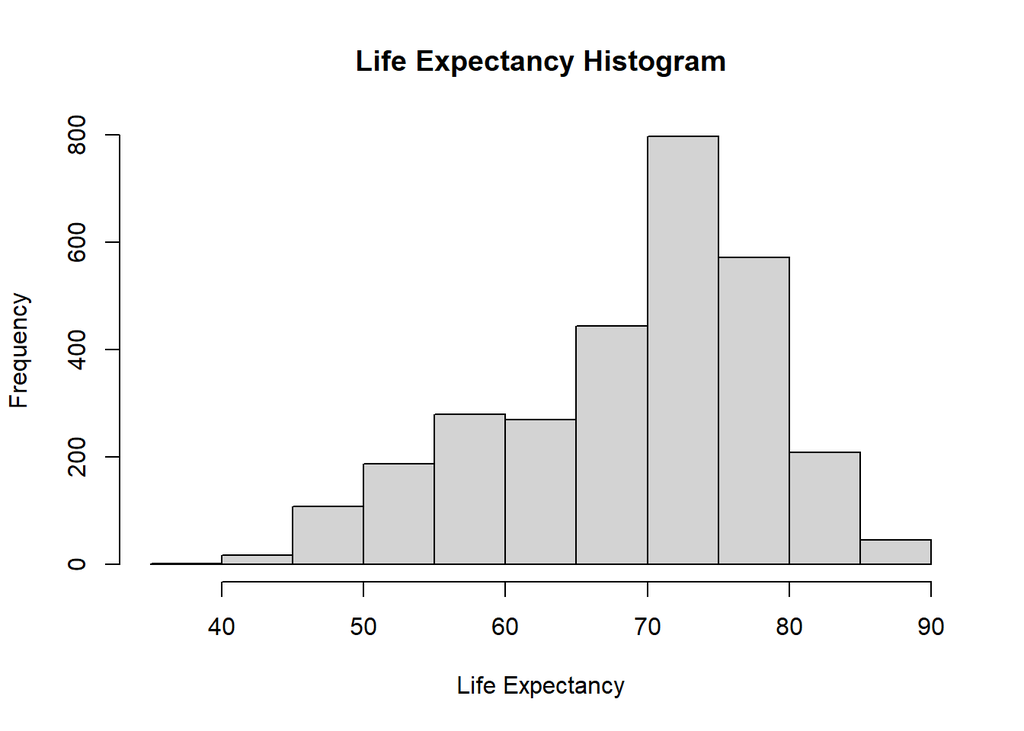

```r
# plot histogram of life expectancy
hist(df$Life.expectancy, main = "Life Expectancy Histogram", xlab = "Life Expectancy")
```

```r
summary(df$Life.expectancy)
```

```
##    Min. 1st Qu.  Median    Mean 3rd Qu.    Max.    NA's
##   36.30   63.10   72.10   69.22   75.70   89.00      10
```

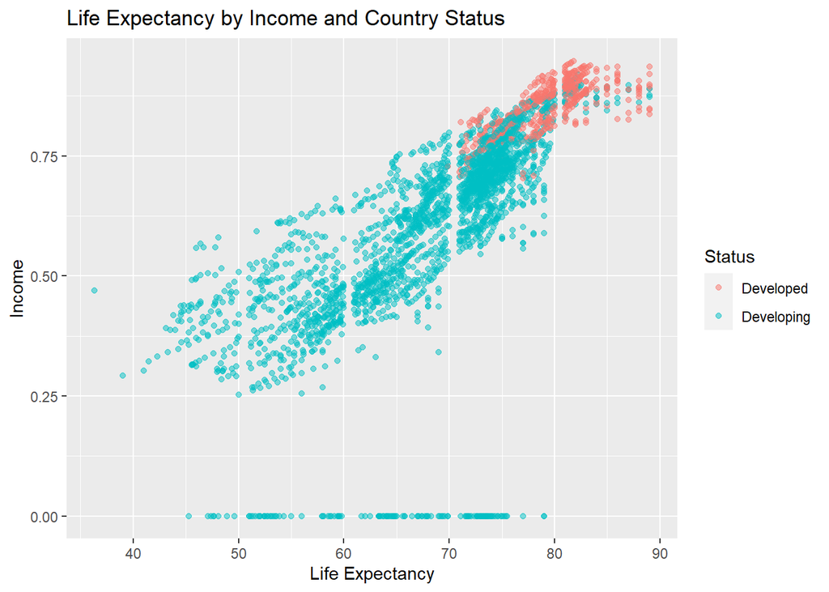

```r
# Plot Life Expectancy by Income and Country Status
ggplot(df, aes(Life.expectancy, Income.composition.of.resources)) +
  geom_point(aes(color = Status), alpha = 0.5) +
  labs(title = "Life Expectancy by Income and Country Status",
       x = "Life Expectancy", y = "Income")
```

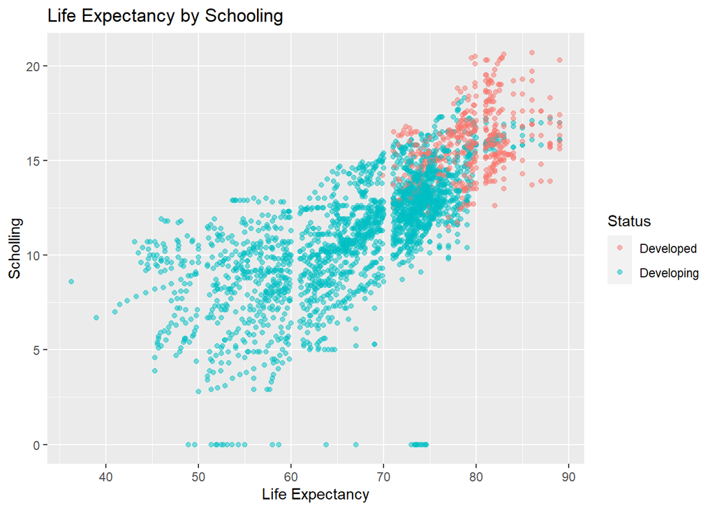

```r
# Plot Life Expectancy by Schooling
ggplot(df, aes(Life.expectancy, Schooling)) +
  geom_point(aes(color = Status), alpha = 0.5)+
  labs(title = "Life Expectancy by Schooling", x = "Life Expectancy", y ="Scholling")
```

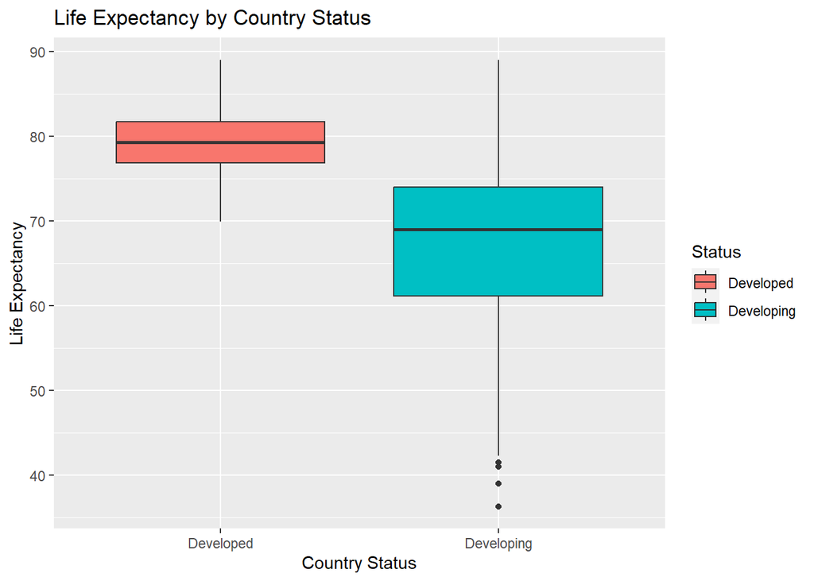

```r
# Boxplot Life Expectancy by Country Status
ggplot(df,aes(x=Status, y=Life.expectancy, fill= Status)) +
  geom_boxplot() +
  labs(title = "Life Expectancy by Country Status", x = "Country Status", y = "Life Expectancy")
```

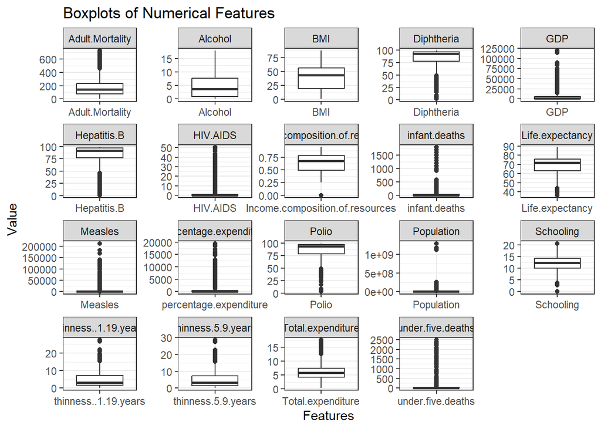

```r
# Plot box plots of numeric variables
df %>%
  select(4:22) %>%
  gather() %>%
  ggplot(aes(x = key, y = value)) +
  geom_boxplot() +
  labs(title = "Boxplots of Numerical Features", x = "Features", y = "Value") +
  facet_wrap(~key, scales = "free") +
  theme_bw()
```

**Data Cleansing and Transformation**

```r
# total number of missing values in each columns
colSums(is.na(df))
```

```
##                         Country                            Year
##                               0                               0
##                          Status                 Life.expectancy
##                               0                              10
##                 Adult.Mortality                   infant.deaths
##                              10                               0
##                         Alcohol          percentage.expenditure
##                             194                               0
##                     Hepatitis.B                         Measles
##                             553                               0
##                             BMI               under.five.deaths
##                              34                               0
##                           Polio               Total.expenditure
##                              19                             226
##                      Diphtheria                        HIV.AIDS
##                              19                               0
##                             GDP                      Population
##                             448                             652
##            thinness..1.19.years              thinness.5.9.years
##                              34                              34
## Income.composition.of.resources                       Schooling
##                             167                             163
```

```r
# fill missing values with respective mean values
for(i in 1:ncol(df)){
  df[is.na(df[,i]), i] <- mean(df[,i], na.rm = TRUE)
}
```

Filling in missing values of features with their mean allows us to preserve the sample size and use all available data in the analysis. This is important for maximizing the statistical power of the analysis and reducing the uncertainty of the estimates.

```r
# numeric predictors
num.cols <- c('Adult.Mortality', 'infant.deaths', 'Alcohol', 'percentage.expenditure', 'Hepatitis.B',
              'Measles', 'BMI', 'under.five.deaths', 'Polio', 'Total.expenditure', 'Diphtheria',
              'HIV.AIDS', 'GDP', 'Population', 'thinness..1.19.years', 'thinness.5.9.years',
              'Income.composition.of.resources', 'Schooling')

# standardize the numeric predictors using the scale() function
df[num.cols] <- apply(df[num.cols], 2, scale)
```

Standardizing numeric predictors in linear regression, can help to improve the interpretability. This is due to the fact that standardizing the predictors puts them on the same scale, so the coefficients can be interpreted as the change in the response variable for a one-unit change in the predictor, holding all other predictors constant. In addition, it also help to enhance numerical stability, and performance of the model.

```r
# remove outliers points which lies outside the 3 standard deviation zones
df_clean <- df[rowSums(abs(df[num.cols]) < 3) == length(num.cols), ]
```

Since outliers can have a significant impact on the estimated coefficients of the linear regression model. They can bias the regression line and reduce the accuracy of the model. By removing these outliers, we can reduce their influence on the model and improve its accuracy.

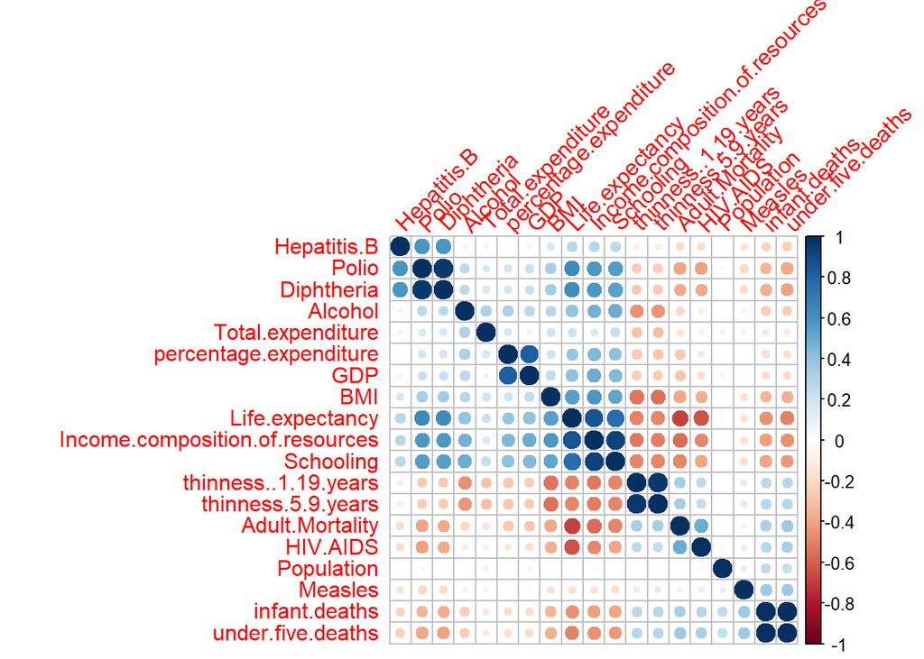

```r
# numeric variables
num.cols1 <- c('Life.expectancy','Adult.Mortality', 'infant.deaths', 'Alcohol', 'percentage.expenditure',
               'Hepatitis.B', 'Measles', 'BMI', 'under.five.deaths', 'Polio', 'Total.expenditure',
               'Diphtheria', 'HIV.AIDS', 'GDP', 'Population', 'thinness..1.19.years',
               'thinness.5.9.years', 'Income.composition.of.resources', 'Schooling')

# display correlation between numeric variables
corrplot(cor(df_clean[,num.cols1]), method = "circle", order = "hclust",
         tl.srt = 45)
```

```r
# remove Country variable from predictors list
df_clean <- select(df_clean,2:22)
```

I would like to exclude the Country variable from the linear regression model and focus on the other relevant predictor variables in the dataset. This can help to simplify the model and improve the interpretability and generalization performance of the model.

**Perform a Linear Regression and comment on the output**

```r
# Split the data into training and testing
set.seed(5420)
sample <- sample(c(TRUE, FALSE), nrow(df_clean), replace=TRUE, prob=c(0.80,0.20))
train <- df_clean[sample, ]
test <- df_clean[!sample, ]
y.test <- df_clean[!sample, ]$Life.expectancy

# Fit full model
model.full = lm(Life.expectancy ~ ., data=train)
summary(model.full)
```

```
##
## Call:
## lm(formula = Life.expectancy ~ ., data = train)
##
## Residuals:
##      Min       1Q   Median       3Q      Max
## -17.4880  -1.7839  -0.0792   1.7169  15.1018
##
## Coefficients:
##                                  Estimate Std. Error t value Pr(>|t|)
## (Intercept)                     -87.64494   37.80977  -2.318 0.020564 *
## Year                              0.07814    0.01884   4.148 3.52e-05 ***
## StatusDeveloping                 -1.73175    0.28196  -6.142 1.01e-09 ***
## Adult.Mortality                  -2.05223    0.12322 -16.655  < 2e-16 ***
## infant.deaths                    11.19408    2.62318   4.267 2.09e-05 ***
## Alcohol                          -0.12326    0.11400  -1.081 0.279747
## percentage.expenditure            0.61497    0.28363   2.168 0.030279 *
## Hepatitis.B                      -0.98082    0.16810  -5.835 6.43e-09 ***
## Measles                          -0.12543    0.30872  -0.406 0.684584
## BMI                              -0.06335    0.11042  -0.574 0.566208
## under.five.deaths               -13.04227    2.58069  -5.054 4.79e-07 ***
## Polio                             1.53144    0.53188   2.879 0.004035 **
## Total.expenditure                 0.36554    0.10130   3.609 0.000317 ***
## Diphtheria                        1.10798    0.52290   2.119 0.034239 *
## HIV.AIDS                         -3.33176    0.22918 -14.538  < 2e-16 ***
## GDP                              -0.35175    0.23517  -1.496 0.134908
## Population                        0.50281    0.29760   1.690 0.091295 .
## thinness..1.19.years              0.46034    0.38487   1.196 0.231823
## thinness.5.9.years               -0.93410    0.38633  -2.418 0.015714 *
## Income.composition.of.resources   6.49033    0.34459  18.835  < 2e-16 ***
## Schooling                        -1.02309    0.24773  -4.130 3.80e-05 ***
## ---
## Signif. codes:  0 '***' 0.001 '**' 0.01 '*' 0.05 '.' 0.1 ' ' 1
##
## Residual standard error: 3.385 on 1716 degrees of freedom
## Multiple R-squared:  0.8502, Adjusted R-squared:  0.8485
## F-statistic: 487.1 on 20 and 1716 DF,  p-value: < 2.2e-16
```

Year, Country Status, Adult.Mortality, infant.deaths, percentage.expenditure, Hepatitis.B, under.five.deaths, Polio, Total.expenditure, Diphtheria, HIV.ADIS, thinness.5.9.years, Income and Schooling are statistically significant as their p-values are below 0.05 or near zero. The remaining predictors are not statistical significance.

```r
# build model using only predictors that are statistical significant based on full model result.

model.finetuned <- lm(Life.expectancy ~ .-Alcohol-Measles-BMI-GDP-Population-thinness..1.19.years,
                      data = train)
summary(model.finetuned)
```

```
##
## Call:
## lm(formula = Life.expectancy ~ . - Alcohol - Measles - BMI -
##     GDP - Population - thinness..1.19.years, data = train)
##
## Residuals:
##      Min       1Q   Median       3Q      Max
## -17.5886  -1.7846  -0.0984   1.7513  14.9285
##
## Coefficients:
##                                  Estimate Std. Error t value Pr(>|t|)
## (Intercept)                     -88.89586   36.82684  -2.414 0.015887 *
## Year                              0.07872    0.01835   4.289 1.89e-05 ***
## StatusDeveloping                 -1.59550    0.25991  -6.139 1.03e-09 ***
## Adult.Mortality                  -2.06526    0.12197 -16.932  < 2e-16 ***
## infant.deaths                    11.28561    2.58469   4.366 1.34e-05 ***
## percentage.expenditure            0.32232    0.18160   1.775 0.076098 .
## Hepatitis.B                      -0.97222    0.16708  -5.819 7.05e-09 ***
## under.five.deaths               -12.96208    2.55341  -5.076 4.26e-07 ***
## Polio                             1.59081    0.52789   3.014 0.002620 **
## Total.expenditure                 0.34979    0.09932   3.522 0.000440 ***
## Diphtheria                        1.06007    0.52066   2.036 0.041902 *
## HIV.AIDS                         -3.36658    0.22663 -14.855  < 2e-16 ***
## thinness.5.9.years               -0.46060    0.12006  -3.836 0.000129 ***
## Income.composition.of.resources   6.33235    0.33105  19.128  < 2e-16 ***
## Schooling                        -1.00930    0.24475  -4.124 3.90e-05 ***
## ---
## Signif. codes:  0 '***' 0.001 '**' 0.01 '*' 0.05 '.' 0.1 ' ' 1
##
## Residual standard error: 3.387 on 1722 degrees of freedom
## Multiple R-squared:  0.8496, Adjusted R-squared:  0.8484
## F-statistic: 694.8 on 14 and 1722 DF,  p-value: < 2.2e-16
```

The p-value < 2.2e-16 for a F-statistic of 694.8 of the fine-tuned model shows significant evidence of a relationship between the predictors and the life expectancy. The adjusted R-squared and residual standard error of finetuned model is similar to the full model.

**Print out algorithm performance**

```r
# predict test data by finetuned model
pred <- predict(model.finetuned, newdata=test)
# Checking RMSE
rmse(pred,y.test)
```

```
## [1] 3.049673
```

The RSEM is 3.049673 is slightly less than the RSME of train data.

```r
# adjusted R^2
summary(model.finetuned)$adj.r.squared
```

```
## [1] 0.8483796
```

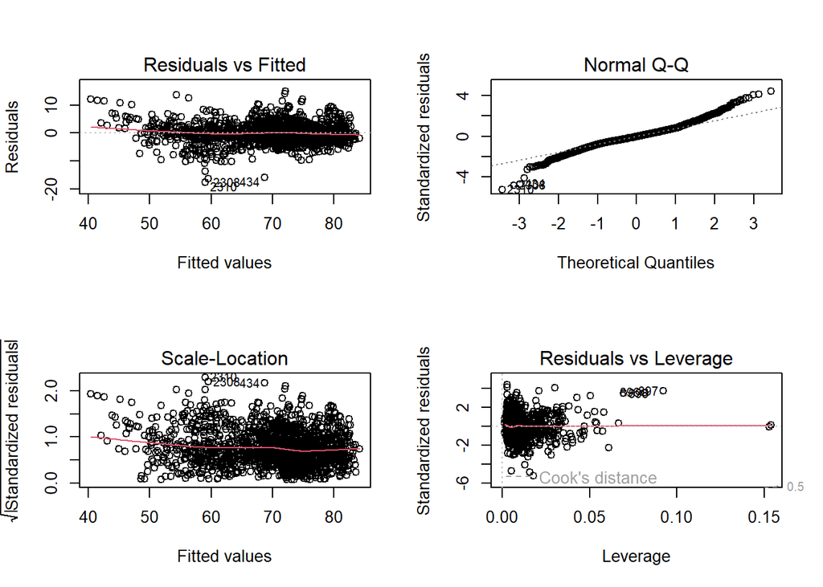

```r
# check linearity assumptions
par(mfrow = (c(2,2)))
plot(model.finetuned)
```

The residuals v fitted values chart doesn’t show any distinct shape, the model appears to be a good fit to the data.

**Iterate and improve algorithm performance**

The stepwise regression with forward selection was implemented in order to find the subset of variables in the data set resulting in the best performing model, which has the lowest prediction error. The process starts with no predictors in the model, iteratively adds the most contributive predictors, and stops when the improvement is no longer statistically significant.

I employed 10-fold cross-validation to estimate the average prediction error (as measured by RMSE) of each model. By comparing the RMSE of all models, the statistical metric allowed for automatic selection of the best performing model, defined as the one that minimizes RMSE.

```r
# Set seed for reproducibility
set.seed(5420)

# Train the model
step.model <- caret::train(Life.expectancy ~ ., data = train,
                    method = "leapForward",
                    tuneGrid = data.frame(nvmax = 1:10),
                    trControl = trainControl(method = "cv", number = 10)
                    )
step.model$results
```

```
##    nvmax     RMSE  Rsquared      MAE    RMSESD RsquaredSD     MAESD
## 1      1 4.522170 0.7309066 3.190404 0.4100065 0.03196446 0.2102856
## 2      2 4.065351 0.7825227 2.814002 0.3990016 0.02852517 0.2071707
## 3      3 3.716837 0.8185923 2.614511 0.3176874 0.02284922 0.1765104
## 4      4 3.560386 0.8333413 2.595667 0.3500215 0.02426013 0.1938835
## 5      5 3.528556 0.8364957 2.576650 0.3340165 0.02289006 0.2009754
## 6      6 3.502017 0.8390696 2.555844 0.3339656 0.02255515 0.1983093
## 7      7 3.468083 0.8420673 2.541765 0.3490426 0.02363989 0.2129959
## 8      8 3.466417 0.8421571 2.534541 0.3353247 0.02171486 0.1961085
## 9      9 3.461715 0.8424975 2.527683 0.3413155 0.02260332 0.1928478
## 10    10 3.466910 0.8416694 2.519723 0.3601406 0.02519516 0.2163390
```

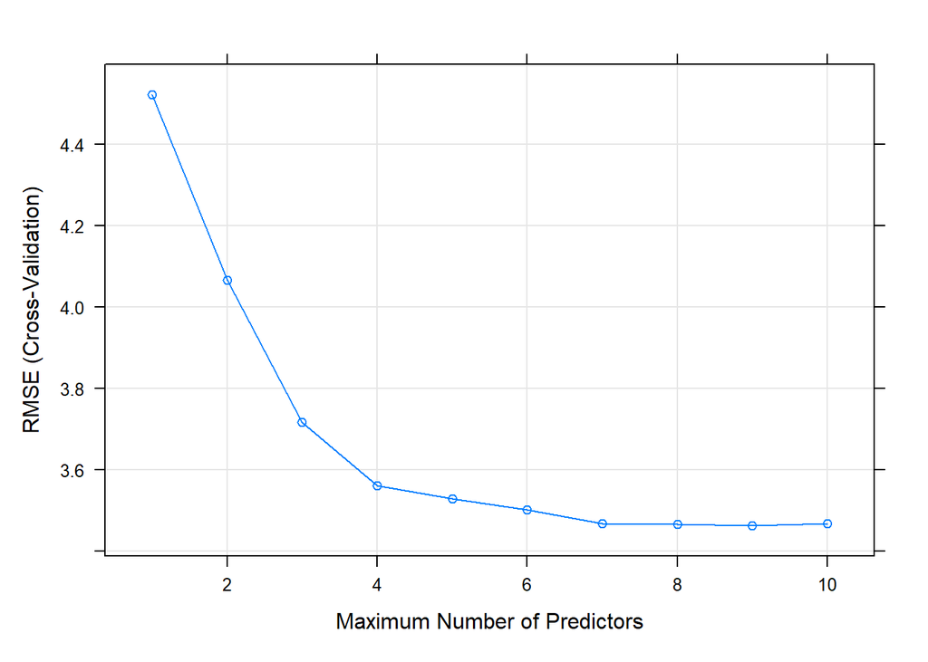

```r
# plot step model
plot(step.model)
```

Based on the plot of step model the optimum number of predictors should be used for linear regression to predict life expectancy in this dataset is 9, which gives the lowest RMSE value.

```r
# the best tune model
step.model$bestTune
```

```
##   nvmax
## 9     9
```

```r
# make predictions for test data
predictions <- step.model %>% predict(test)

# model performance metrics
data.frame(
  RMSE = caret::RMSE(predictions, test$Life.expectancy),
  Rsquare = caret::R2(predictions, test$Life.expectancy)
)
```

```
##       RMSE   Rsquare
## 1 3.050378 0.8672161
```